# Chapter 9 lab

## Linear SVM Classifier

We are going to generate a simulated data.

```r
set.seed(101)
x = matrix(rnorm(40),20,2)
y = rep(c(-1,1), c(10,10))
```

We are moving the mean from 0 to 1 in `x` for index positions in `y` having `y=1`.

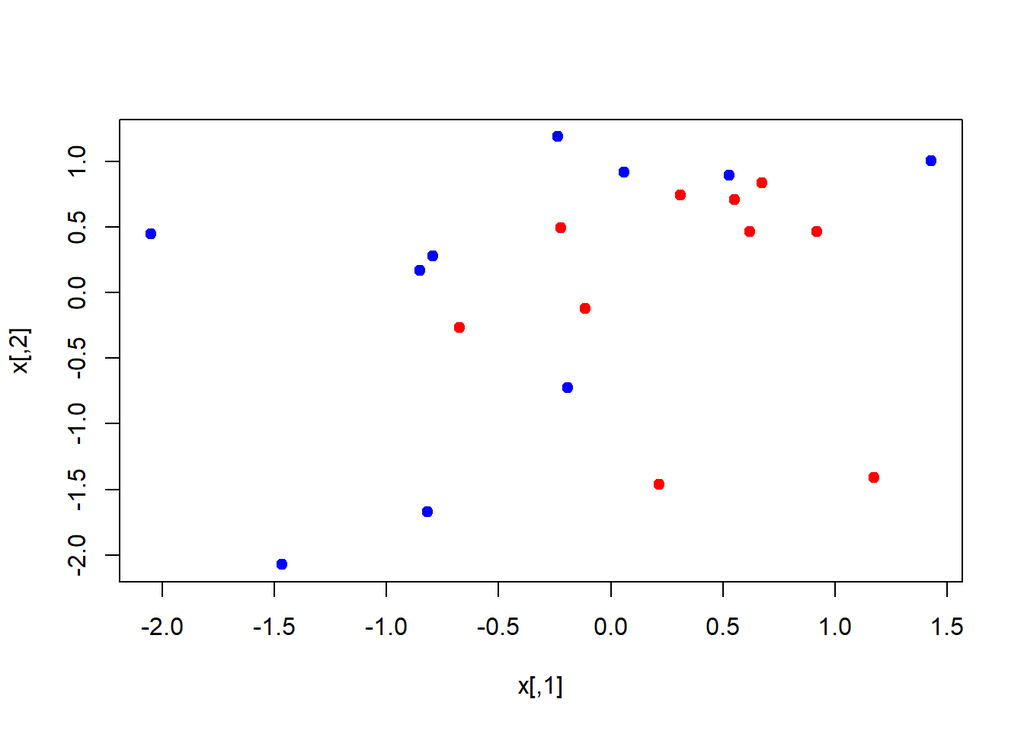

```r
x[y=1,] = x[y=1,]+1
plot(x,col=y+3,pch=19)
```

Now we will load the package. The `svm()` function in `e1071` library can be used to fit support vector classifier when argument `kernel = linear` is used.

`cost` argument allows us to specify the cost of violation to margin.

When `cost` argument is small, then the margins will be wide and many data points(support vector) will be on wrong side of margin whereas when `cost` argument is large margins will be narrow and few support vectors will be on margin or violating the margin.

```r
library(e1071)
dat = data.frame(x,y = as.factor(y))
svmfit = svm(y~., data= dat, kernel="linear", cost=10, scale=FALSE)
print(svmfit)
```

```
##
## Call:
## svm(formula = y ~ ., data = dat, kernel = "linear", cost = 10,
##     scale = FALSE)
##
##
## Parameters:
##    SVM-Type:  C-classification
##  SVM-Kernel:  linear
##        cost:  10
##
## Number of Support Vectors:  14
```

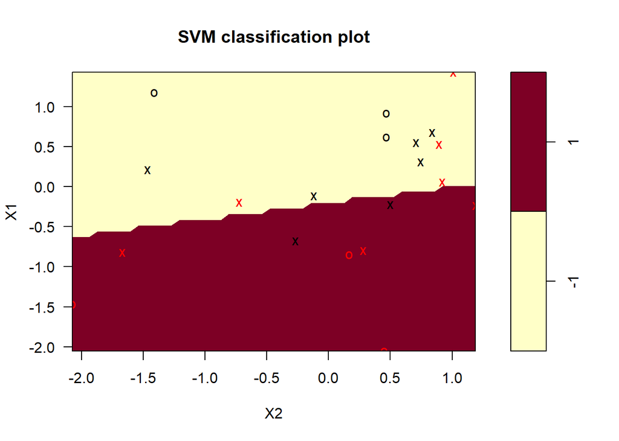

```r
plot(svmfit,dat)
```

Noting that `X1` in on y- axis and `X2` on x- axis in contrast to usual plot function. support vectors are plotted as `X` where remaining observations as `o`.

We can obtain the identity of support vectors.

```r
svmfit$index
```

```
##  [1]  1  2  3  4  5  8 10 11 12 13 15 16 18 19
```

We can also make our own plot for support vector. Forst thing we will make a grid of values for `X1` and `X2`

We will use function `expand.grid` and produce the coordinates of `n*n` points on a lattice covering whole domain of `x`. Having made the lattice, we can make prediction at each point on lattice and then plot the lattice, color - coded according to classification. We can then see the the decision boundary.

We will be constructing a function `make.grid` with arguments as data matrix `x` and no. of points in each direction.

```r
make.grid=function(x,n=75){
  grange = apply(x,2,range) #grange will contain range of each column of x; 2 indicates apply over column
  x1 = seq(from=grange[1,1], to= grange[2,1], length= n)
  x2 = seq(from= grange[1,2], to= grange[2,2], length = n)
  expand.grid(X1=x1, X2=x2) #this function takes the uniformly spaced x1 and x2 and makes a lattice
}
```

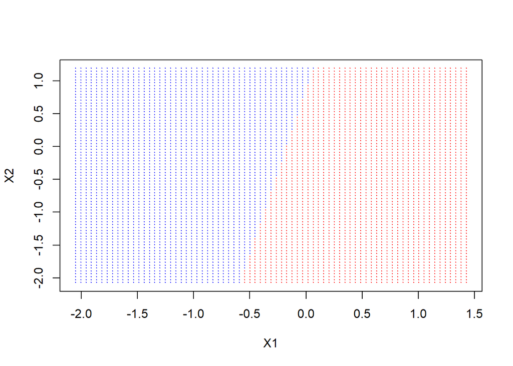

```r
xgrid = make.grid(x)
ygrid = predict(svmfit,xgrid)
plot(xgrid, col=c("red","blue")[as.numeric(ygrid)], pch=20, cex=0.2)
```

Now, we will put our original points on this plot:

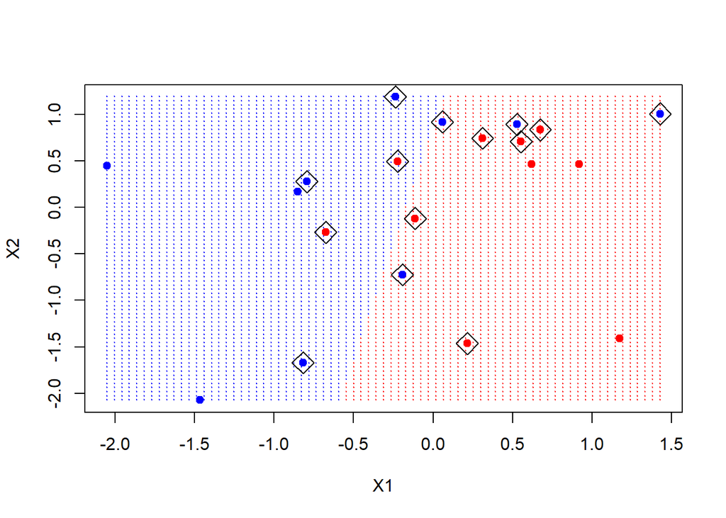

```r
plot(xgrid, col= c("red","blue")[as.numeric(ygrid)], pch=20, cex=0.2)
points(x, col=y+3, pch=19)
points(x[svmfit$index,], pch=5, cex=2)
```

We can use a inbuilt function `tune()` in `e1071` library to perform cross validation to select `cost` parameter. In order to use this function, we need to pass relevant information about set of models that are in considersation. By default, `tune()` performs 10-fold cross validation.

```r
tune.out = tune(svm,y~., data= dat, kernel = "linear", ranges  = list(cost=c(0.001,0.01,0.1,1,5,10,100)))
```

```r
summary(tune.out)
```

```
##
## Parameter tuning of 'svm':
##
## - sampling method: 10-fold cross validation
##
## - best parameters:
##  cost
##     5
##
## - best performance: 0.35
##
## - Detailed performance results:
##    cost error dispersion
## 1 1e-03  0.80  0.4216370
## 2 1e-02  0.80  0.4216370
## 3 1e-01  0.75  0.4249183
## 4 1e+00  0.40  0.4594683
## 5 5e+00  0.35  0.4116363
## 6 1e+01  0.35  0.4116363
## 7 1e+02  0.35  0.4116363
```

`cost=5` results in lowest cross validation error.

Best model could be accessed through:-

```r
bestmod = tune.out$best.model
summary(bestmod)
```

```
##
## Call:
## best.tune(method = svm, train.x = y ~ ., data = dat, ranges = list(cost = c(0.001,
##     0.01, 0.1, 1, 5, 10, 100)), kernel = "linear")
##
##
## Parameters:
##    SVM-Type:  C-classification
##  SVM-Kernel:  linear
##        cost:  5
##
## Number of Support Vectors:  14
##
##  ( 7 7 )
##
##
## Number of Classes:  2
##
## Levels:
##  -1 1
```

It’s not easy in `svm()` to getl linear coefficients.

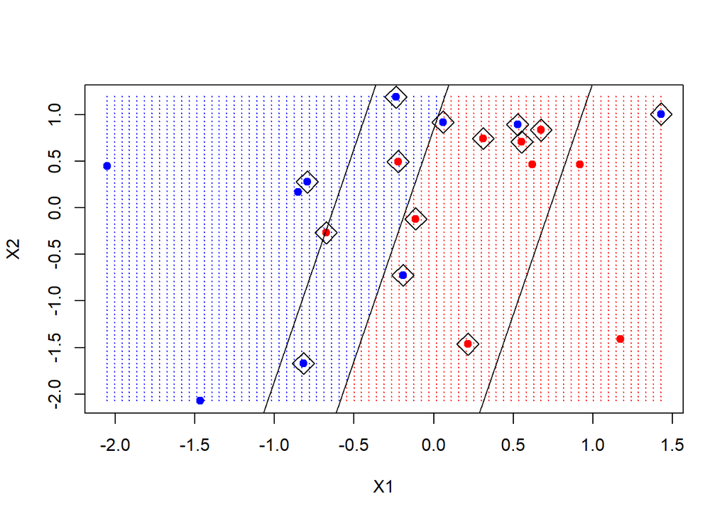

```r
beta = drop(t(svmfit$coefs)%*%x[svmfit$index,])
beta0 = svmfit$rho
plot(xgrid, col=c("red","blue")[as.numeric(ygrid)], pch=20, cex=0.2)
points(x, col= y+3, pch=19)
points(x[svmfit$index,], pch=5, cex=2)
abline(beta0/beta[2], -beta[1]/beta[2]) #first argument is intercept of decision boundary and second one is slope of it.
#now plotting margins
abline(beta0-1/beta[2], -beta[1]/beta[2]) #intercept will change, slope will be same.
abline(beta0+1/beta[2], -beta[1]/beta[2])
```

## Non- Linear SVM Classifier

To fit an SVM using an non-linear kernel, we can use the `svm()` function with different value of `kernel` argument.

To fit an SVM with polynomial kernel we can use `kernel=ploynomial` and for radial, `kernel=radial`.

In polynomial kernel, we use `degree` argument to specify adegree for polyomial.

In radial kernel, we use `gamma` argument to specify value of $\gamma$.

We will Use mixture data set from ESLR data sets.

```r
library(e1071)
load(url("http://www.stanford.edu/~hastie/ElemStatLearn/datasets/ESL.mixture.rda"))
names(ESL.mixture)
```

```
## [1] "x"        "y"        "xnew"     "prob"     "marginal" "px1"
## [7] "px2"      "means"
```

```r
rm(x,y)
attach(ESL.mixture)
dat = data.frame(x,y = as.factor(y))
```

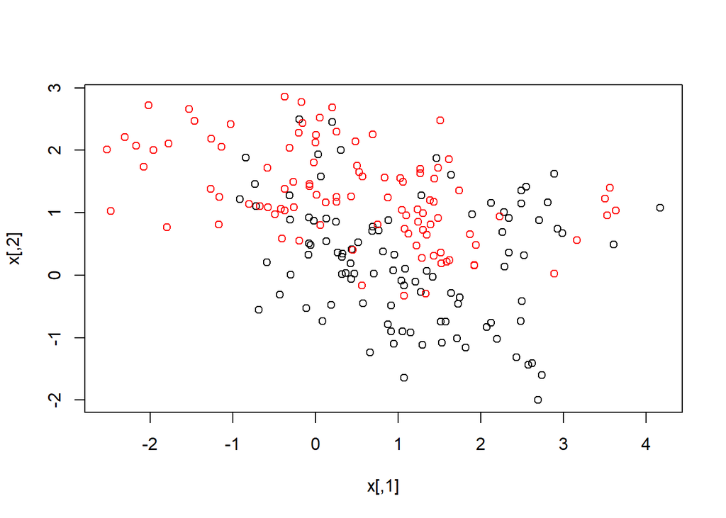

```r
plot(x, col=y+1)
```

From above plot we can see that class boundary is non-linear.

Fitting SVM using `svm()` function with radial kernel and $\gamma = 1$.

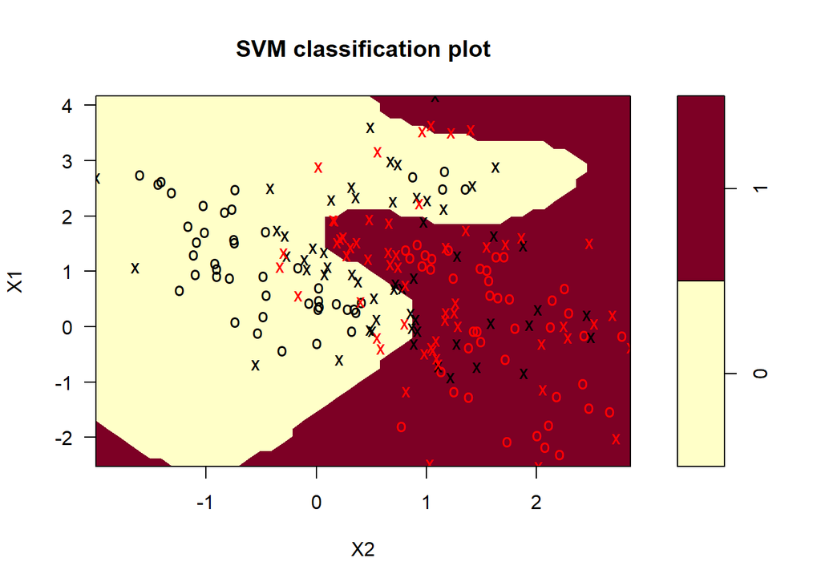

```r
svmfit  = svm(y~., data=dat, kernel = "radial", gamma=1, cost=1)
plot(svmfit, dat)
```

`summary()` can be used to obtain information about svm fit.

```r
summary(svmfit)
```

```
##
## Call:
## svm(formula = y ~ ., data = dat, kernel = "radial", gamma = 1,
##     cost = 1)
##
##
## Parameters:
##    SVM-Type:  C-classification
##  SVM-Kernel:  radial
##        cost:  1
##
## Number of Support Vectors:  114
##
##  ( 56 58 )
##
##
## Number of Classes:  2
##
## Levels:
##  0 1
```

We can perform cross validation here using `tune()` to select best `cost` and $\gamma$.

```r
tune.out = tune(svm, y~., data= dat, kernel = "radial", ranges = list(cost= c(0.1,1,10,100,1000), gamma = c(0.5,1,2,3,4)))
summary(tune.out)
```

```
##
## Parameter tuning of 'svm':
##
## - sampling method: 10-fold cross validation
##
## - best parameters:
##  cost gamma
##     1     4
##
## - best performance: 0.15
##
## - Detailed performance results:
##     cost gamma error dispersion
## 1  1e-01   0.5 0.280 0.08232726
## 2  1e+00   0.5 0.230 0.07149204
## 3  1e+01   0.5 0.230 0.07888106
## 4  1e+02   0.5 0.195 0.09846037
## 5  1e+03   0.5 0.200 0.09128709
## 6  1e-01   1.0 0.255 0.08644202
## 7  1e+00   1.0 0.200 0.07453560
## 8  1e+01   1.0 0.170 0.10327956
## 9  1e+02   1.0 0.175 0.10865337
## 10 1e+03   1.0 0.185 0.09442810
## 11 1e-01   2.0 0.230 0.09189366
## 12 1e+00   2.0 0.165 0.10554093
## 13 1e+01   2.0 0.160 0.08755950
## 14 1e+02   2.0 0.185 0.10287533
## 15 1e+03   2.0 0.220 0.11105554
## 16 1e-01   3.0 0.225 0.10341395
## 17 1e+00   3.0 0.160 0.09368980
## 18 1e+01   3.0 0.165 0.09143911
## 19 1e+02   3.0 0.210 0.10749677
## 20 1e+03   3.0 0.255 0.12572015
## 21 1e-01   4.0 0.235 0.10013879
## 22 1e+00   4.0 0.150 0.09428090
## 23 1e+01   4.0 0.175 0.10069205
## 24 1e+02   4.0 0.215 0.10287533
## 25 1e+03   4.0 0.280 0.13784049
```

As in linear classifier, now we will make a grid and make predictions on it.

These data have the grid points for each variable included on the data frame.

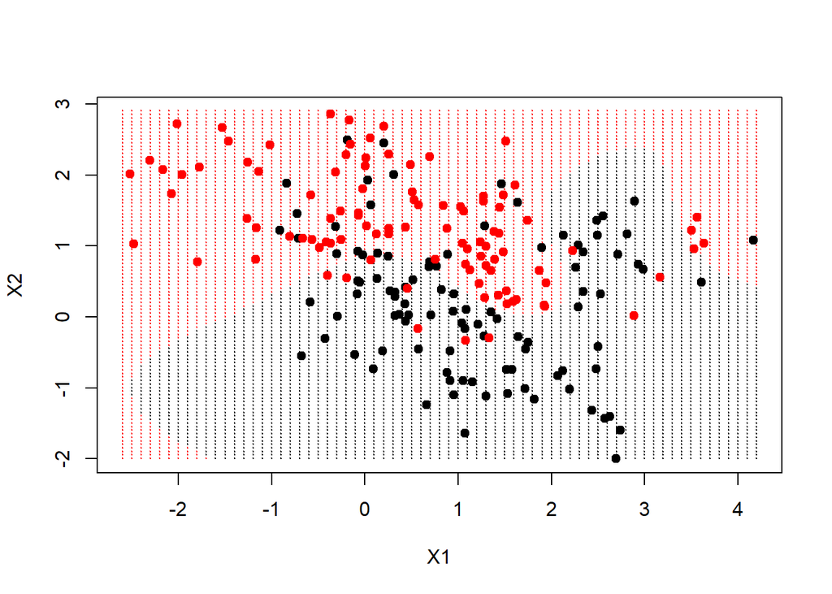

```r
xgrid = expand.grid(X1=px1, X2=px2)
ygrid = predict(svmfit,xgrid)
plot(xgrid,col=as.numeric(ygrid), pch=20, cex=0.2)
points(x, col= y+1, pch=19)
```

We can have `predict()` function produce the actual function estimates at each of ou grid points. We will be doing that by using `contour()` function. We also have `prob` variable in dataframe which gives us true probability for class 1 of data, at the gridpoints.

If we plot at 0.5 contour, we will have true decision boundary which is “Bayes decision boundary” - the best classifier boundary.

```r
func = predict(svmfit,xgrid, decision.values = TRUE)
```

we set up decision.value = TRUE as we want to get the function not just classification.

```r
func = attributes(func)$decision
```

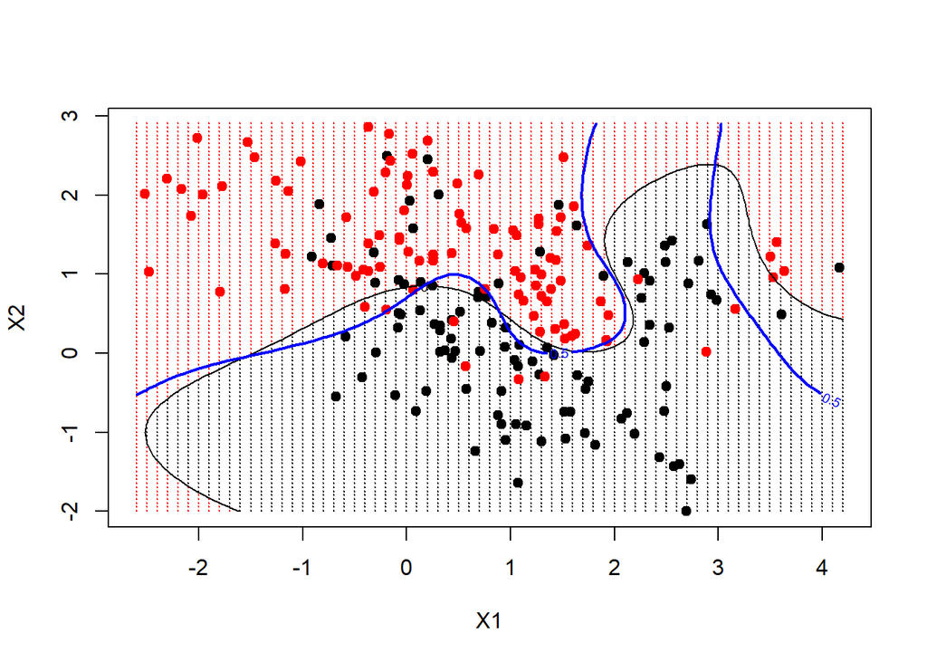

```r
plot(xgrid,col=as.numeric(ygrid), pch=20, cex= 0.2)
points(x, col= y+1, pch=19)

contour(px1,px2,matrix(func, length(px1), length(px2)), level=0, add= TRUE )

contour(px1, px2, matrix(prob, length(px1), length(px2)), level= 0.5, add= TRUE, col="blue", lwd=2)#Bayes Decision Boundary
```

## ROC Curves

`ROCR` package can be used to produce ROC curves

```r
library(ROCR)
```

We will first write a short function to plot a ROC curve given numerical score for each observation `pred` and a vector containing the class label for each observation `truth`.

```r
rocplot = function(pred, truth, ...){
  predob = prediction(pred, truth)
  perf = performance(predob, "tpr","fpr")
  plot(perf, ...)
}
```

SVM output class labels for each observation. But we can also obtain fitted values for each observation i.e. value of function.

The sign of fitted value determines on which side of decision boundary the observation lies. If fitted value exceeds zero then the observation is assigned to one class or if it is less than zero then it is assigned to other. To get fitted values, we use `decision.values=TRUE` when fitting `svm()`. Then the `predict()` will output fitted values.

```r
svmfit.func = svm(y~., data=dat, kernel="radial", gamma=2, cost=1, decision.values= TRUE)
fitted = predict(svmfit.func,dat,decision.values = TRUE)
fitted = attributes(fitted)$decision.values
```

Now, We can produce ROC plot:

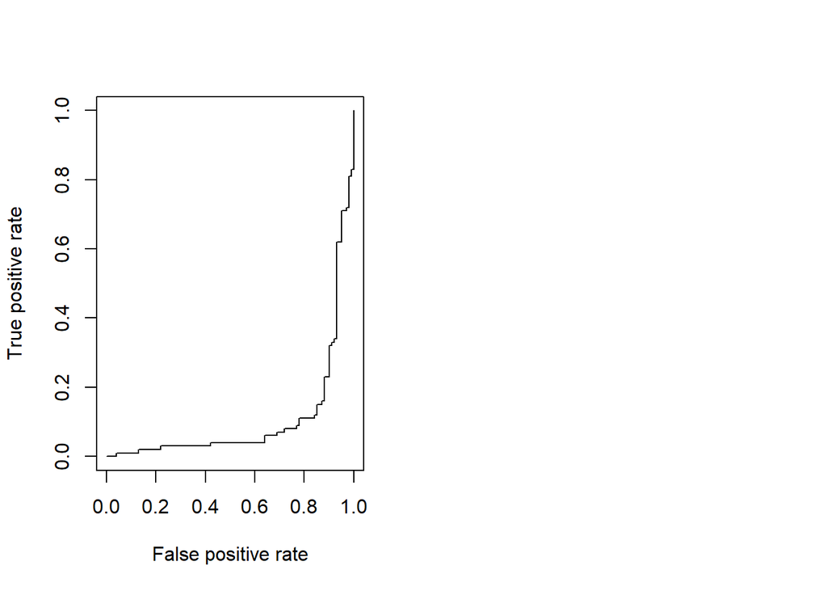

```r
par(mfrow=c(1,2))
rocplot(fitted, dat[,"y"])
```